# Exploratory Factor Analysis - Basic

O Rodriguez de Rivera Ortega, PhD

University of Exeter

Factor Analysis (FA) is an exploratory data analysis method used to search influential underlying factors or latent variables from a set of observed variables. It helps in data interpretations by reducing the number of variables. It extracts maximum common variance from all variables and puts them into a common score.

```r
library(psych)
library(ggplot2)
library(corrplot) #plotting correlation matrices
library(GPArotation) #methods for factor rotation
library(nFactors)  #methods for determining the number of factors
```

### Choosing the number of factors, etc…

Prelim - Reading in Repeated Measures Data

```r
#Reading the data from web location
#set filepath for data file
filepath <- "https://quantdev.ssri.psu.edu/sites/qdev/files/ptechdata.csv"
#read in the .csv file using the url() function
pdat <- read.csv(file=filepath,header=TRUE)
```

Lets split the data and remove the id variable

```r
#splitting data
pdat1 <- pdat[pdat$id==1,-1]
pdat2 <- pdat[pdat$id==2,-1]
```

Lets have a quick look at the first sample and the descriptives.

```r
#data structure
head(pdat1,10)
```

```
##       v1    v2    v3    v4    v5    v6    v7    v8    v9
## 1  -0.84 -0.27 -0.59 -0.97 -0.72 -1.86  1.11  0.46  0.09
## 2  -0.04 -0.33 -0.54  2.57  1.30  0.59  1.42  2.56  0.66
## 3   0.34 -0.23  0.99 -1.84 -1.62 -1.55  1.05  0.22  0.60
## 4  -1.01 -1.96 -1.17 -2.93 -1.75 -1.89 -0.51 -0.07  1.14
## 5   2.02  0.21  0.97  0.13 -0.01 -0.88 -1.22  0.54 -0.28
## 6  -0.24 -0.19  0.23  0.80  1.06  1.61  1.31 -1.10  0.26
## 7  -0.61 -1.37  0.15 -0.68 -1.50 -0.44 -1.63  1.40  1.79
## 8  -1.26 -2.59 -1.10 -0.40 -0.66  0.29 -1.45 -1.06  0.15
## 9   0.23  0.25 -0.21  0.23 -0.42  1.01  0.15  1.16 -0.36
## 10  1.01 -0.08  1.95  1.14 -0.06 -0.48 -0.62 -1.27 -0.08
```

```r
#descriptives
describe(pdat1)
```

```
##    vars   n  mean   sd median trimmed  mad   min  max range  skew kurtosis   se
## v1    1 100  0.00 0.95   0.03    0.00 0.96 -2.33 2.44  4.77  0.04    -0.41 0.10
## v2    2 100 -0.14 0.97  -0.11   -0.12 0.90 -2.59 2.07  4.66 -0.21    -0.21 0.10
## v3    3 100  0.04 0.91   0.09    0.08 0.90 -3.11 2.10  5.21 -0.46     0.72 0.09
## v4    4 100 -0.13 0.93  -0.06   -0.11 0.93 -2.93 2.57  5.50 -0.15     0.21 0.09
## v5    5 100 -0.18 0.85  -0.29   -0.20 0.83 -2.04 1.75  3.79  0.25    -0.31 0.09
## v6    6 100 -0.01 0.98   0.06    0.01 0.81 -2.37 2.24  4.61 -0.21    -0.34 0.10
## v7    7 100  0.12 0.94   0.12    0.12 1.02 -1.91 2.14  4.05  0.04    -0.68 0.09
## v8    8 100 -0.03 1.04   0.00   -0.03 0.93 -2.58 2.56  5.14 -0.05    -0.32 0.10
## v9    9 100  0.17 0.96   0.26    0.18 0.93 -2.54 2.47  5.01 -0.20    -0.17 0.10
```

Data appear to already be in standardized form.

Lets look at the raw data.

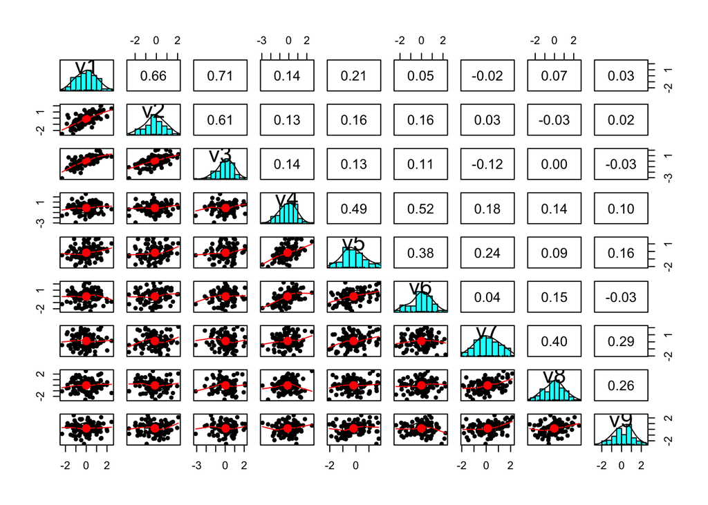

```r
pairs.panels(pdat1)
```

The research question is - can these data be represented by a smaller number of factors?

Store and examine the correlation matrices

```r
#correlation matrix
round(cor(pdat1),2)
```

```
##       v1    v2    v3   v4   v5    v6    v7    v8    v9
## v1  1.00  0.66  0.71 0.14 0.21  0.05 -0.02  0.07  0.03
## v2  0.66  1.00  0.61 0.13 0.16  0.16  0.03 -0.03  0.02
## v3  0.71  0.61  1.00 0.14 0.13  0.11 -0.12  0.00 -0.03
## v4  0.14  0.13  0.14 1.00 0.49  0.52  0.18  0.14  0.10
## v5  0.21  0.16  0.13 0.49 1.00  0.38  0.24  0.09  0.16
## v6  0.05  0.16  0.11 0.52 0.38  1.00  0.04  0.15 -0.03
## v7 -0.02  0.03 -0.12 0.18 0.24  0.04  1.00  0.40  0.29
## v8  0.07 -0.03  0.00 0.14 0.09  0.15  0.40  1.00  0.26
## v9  0.03  0.02 -0.03 0.10 0.16 -0.03  0.29  0.26  1.00
```

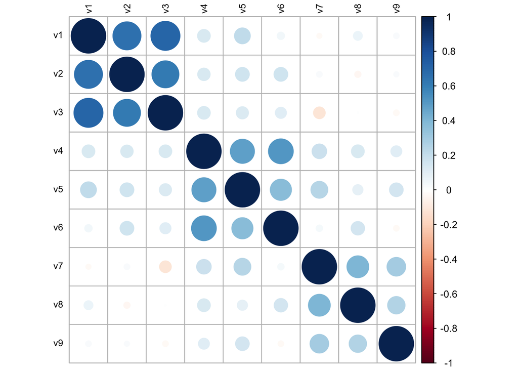

```r
corrplot(cor(pdat1), order = "original", tl.col='black', tl.cex=.75)
```

We see three “groups” of variables that are positively correlated. This gives us hope.

Traditionally, EFA was an analysis of a correlation matrix. Most programs now can also read the raw data directly. We make the correlation matrix to be explicit (and so that we know how that matrix was made - e.g, how the missing data were treated). #Store the correlation matrix of the data into an object

```r
corpdat1 <- cor(pdat1, use="pairwise.complete.obs")
corpdat1
```

```
##             v1          v2           v3        v4         v5          v6
## v1  1.00000000  0.65976178  0.707293038 0.1384304 0.21243923  0.04765664
## v2  0.65976178  1.00000000  0.611290349 0.1317872 0.16188108  0.16125106
## v3  0.70729304  0.61129035  1.000000000 0.1373615 0.12634369  0.10552785
## v4  0.13843038  0.13178718  0.137361546 1.0000000 0.48822168  0.51674523
## v5  0.21243923  0.16188108  0.126343694 0.4882217 1.00000000  0.37730021
## v6  0.04765664  0.16125106  0.105527848 0.5167452 0.37730021  1.00000000
## v7 -0.02354195  0.02976057 -0.116982880 0.1808370 0.24081229  0.03741838
## v8  0.06859518 -0.03458348  0.002804632 0.1398046 0.08966386  0.15383876
## v9  0.02845927  0.02415579 -0.029471278 0.1026108 0.15878760 -0.02887585
##             v7           v8          v9
## v1 -0.02354195  0.068595180  0.02845927
## v2  0.02976057 -0.034583485  0.02415579
## v3 -0.11698288  0.002804632 -0.02947128
## v4  0.18083704  0.139804599  0.10261085
## v5  0.24081229  0.089663855  0.15878760
## v6  0.03741838  0.153838758 -0.02887585
## v7  1.00000000  0.401410299  0.29346736
## v8  0.40141030  1.000000000  0.25623468
## v9  0.29346736  0.256234679  1.00000000
```

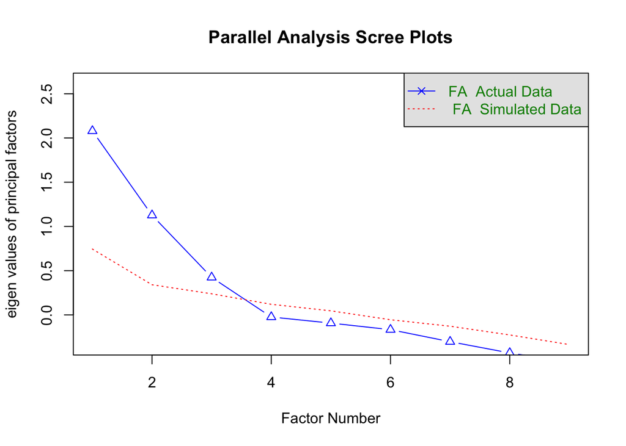

```
## Parallel analysis suggests that the number of factors =  3  and the number of components =  NA
```

```r
#parallel analysis for number of factors
fa.parallel(x=corpdat1, fm="minres", fa="fa")
```

```r
#multiple methods for number of factors
nScree(x=corpdat1,model="factors")
```

```
##   noc naf nparallel nkaiser
## 1   3   3         3       3
```

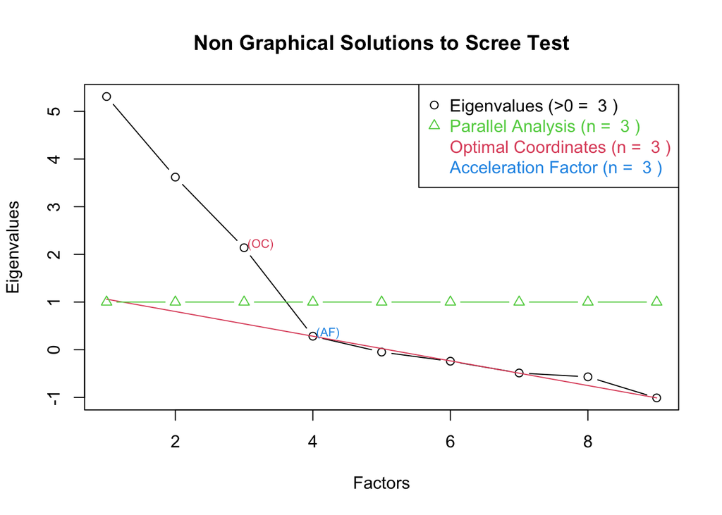

```r
plot(nScree(x=corpdat1,model="factors"))
```

The output here is number of components/factors according to optimal coordinates (noc), acceleration factor (naf), parallel analysis (nparallel), and Kaiser rule (nkaiser).

For these data - everything points to choice of 3 factors.

Now lets run the factor analysis. This time we use the fa() in the psych package, with oblique oblimin rotation (rotate=“oblimin”) and principal factor extraction (fm=“pa”).

```r
EFApdat1_3factor <- fa(r = corpdat1, nfactors = 3,
                       rotate = "oblimin",
                       fm = "pa")
EFApdat1_3factor
```

```
## Factor Analysis using method =  pa
## Call: fa(r = corpdat1, nfactors = 3, rotate = "oblimin", fm = "pa")
## Standardized loadings (pattern matrix) based upon correlation matrix
##      PA1   PA2   PA3   h2   u2 com
## v1  0.90 -0.04  0.06 0.79 0.21 1.0
## v2  0.74  0.05  0.00 0.56 0.44 1.0
## v3  0.80  0.02 -0.10 0.66 0.34 1.0
## v4  0.00  0.78  0.04 0.62 0.38 1.0
## v5  0.09  0.54  0.15 0.38 0.62 1.2
## v6 -0.03  0.70 -0.10 0.46 0.54 1.0
## v7 -0.03  0.01  0.73 0.54 0.46 1.0
## v8  0.02  0.04  0.51 0.27 0.73 1.0
## v9  0.03 -0.03  0.45 0.20 0.80 1.0
##
##                        PA1  PA2  PA3
## SS loadings           2.01 1.41 1.07
## Proportion Var        0.22 0.16 0.12
## Cumulative Var        0.22 0.38 0.50
## Proportion Explained  0.45 0.31 0.24
## Cumulative Proportion 0.45 0.76 1.00
##
##  With factor correlations of
##       PA1  PA2   PA3
## PA1  1.00 0.21 -0.02
## PA2  0.21 1.00  0.26
## PA3 -0.02 0.26  1.00
##
## Mean item complexity =  1
## Test of the hypothesis that 3 factors are sufficient.
##
## df null model =  36  with the objective function =  2.55
## df of  the model are 12  and the objective function was  0.15
##
## The root mean square of the residuals (RMSR) is  0.03
## The df corrected root mean square of the residuals is  0.06
##
## Fit based upon off diagonal values = 0.99
## Measures of factor score adequacy
##                                                    PA1  PA2  PA3
## Correlation of (regression) scores with factors   0.94 0.87 0.81
## Multiple R square of scores with factors          0.88 0.76 0.66
## Minimum correlation of possible factor scores     0.75 0.51 0.32
```

The solution looks pretty good.

Our objective here was data reduction. To make that explicit, we can obtain the factor scores by inputing the raw data matrix instead of the correlation matrix. Additionally, we can specify the ‘scores’ argument as below to get factor scores by a factor score regression method. To get estimated factor scores we must input the raw data.

```r
EFApdat1_3factor <- fa(r = pdat1, nfactors = 3,
                       rotate = "oblimin",
                       fm = "pa",
                       scores="regression")
head(EFApdat1_3factor$scores,10)
```

```
##             PA1        PA2        PA3
## 1  -0.783420678 -1.1506737  0.5983783
## 2  -0.262502699  2.1004885  1.8211517
## 3   0.433115912 -1.7226209  0.3998862
## 4  -1.419724776 -2.6307726 -0.3797518
## 5   1.476386714 -0.1114002 -0.6023405
## 6   0.007833174  1.3577895  0.5681540
## 7  -0.614527322 -0.8404476 -0.5418789
## 8  -1.578440465 -0.3701222 -1.1402610
## 9   0.122523810  0.5020814  0.1907809
## 10  1.232518910  0.5499773 -0.7593508
```

Lets look at the “reduced” data.

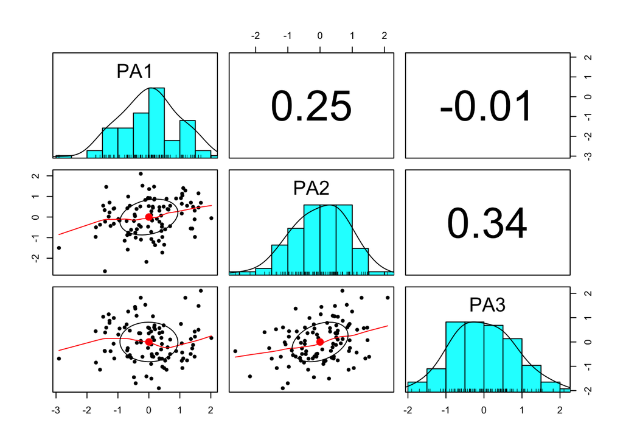

```r
pairs.panels(EFApdat1_3factor$scores)
```

But do not forget that there are also unique factors too. The factors only capture common variance. There may be quite a bit of stuff left over.

Remember that the variance accounted for by the 3 factors is only part of the total variance. Specifically, 0.499181, which we see in the main output

```r
EFApdat1_3factor$Vaccounted[3,3]
```

```
## [1] 0.499181
```

All the other parts are in the uniquenesses and misfit.

```r
#Uniquenesses
round(EFApdat1_3factor$uniquenesses,3)
```

```
##    v1    v2    v3    v4    v5    v6    v7    v8    v9
## 0.209 0.441 0.336 0.379 0.617 0.541 0.458 0.726 0.801
```

```r
#residuals (diagonal removed)
round(EFApdat1_3factor$residual - EFApdat1_3factor$uniquenesses,3)
```

```
##        v1     v2     v3     v4     v5     v6     v7     v8     v9
## v1  0.000 -0.210 -0.214 -0.200 -0.174 -0.246 -0.235 -0.182 -0.220
## v2 -0.443  0.000 -0.434 -0.467 -0.458 -0.399 -0.393 -0.498 -0.435
## v3 -0.341 -0.328  0.000 -0.324 -0.359 -0.334 -0.354 -0.301 -0.338
## v4 -0.371 -0.404 -0.368  0.000 -0.366 -0.386 -0.380 -0.394 -0.365
## v5 -0.581 -0.633 -0.640 -0.603  0.000 -0.622 -0.590 -0.701 -0.576
## v6 -0.579 -0.499 -0.539 -0.548 -0.547  0.000 -0.568 -0.455 -0.589
## v7 -0.484 -0.410 -0.476 -0.458 -0.431 -0.484  0.000 -0.440 -0.490
## v8 -0.699 -0.783 -0.690 -0.741 -0.810 -0.639 -0.708  0.000 -0.701
## v9 -0.812 -0.795 -0.803 -0.787 -0.761 -0.848 -0.834 -0.776  0.000
```

Intersample comparisons - We can look at the comparison of the factor solutions in a second sample (e.g., cross-validation).

Lets run the factor analysis on our second sample, pdat2. First we should check if the number of factors is the same.

```r
#correlation matrix
round(cor(pdat2),2)
```

```
##       v1    v2    v3   v4   v5   v6    v7    v8    v9
## v1  1.00  0.78  0.79 0.21 0.05 0.24 -0.04 -0.13 -0.13
## v2  0.78  1.00  0.69 0.11 0.14 0.26 -0.01 -0.07 -0.15
## v3  0.79  0.69  1.00 0.19 0.01 0.23  0.01 -0.03 -0.11
## v4  0.21  0.11  0.19 1.00 0.49 0.55  0.39  0.29  0.32
## v5  0.05  0.14  0.01 0.49 1.00 0.47  0.30  0.09  0.28
## v6  0.24  0.26  0.23 0.55 0.47 1.00  0.28  0.12  0.31
## v7 -0.04 -0.01  0.01 0.39 0.30 0.28  1.00  0.56  0.52
## v8 -0.13 -0.07 -0.03 0.29 0.09 0.12  0.56  1.00  0.44
## v9 -0.13 -0.15 -0.11 0.32 0.28 0.31  0.52  0.44  1.00
```

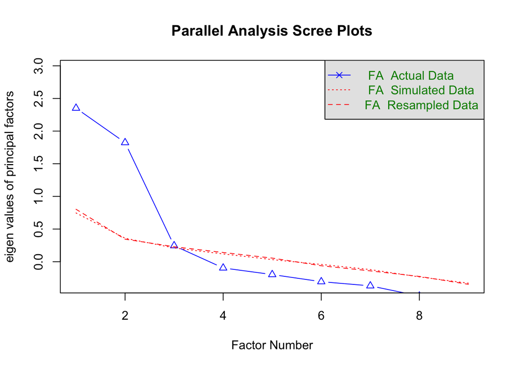

```
## Parallel analysis suggests that the number of factors =  2  and the number of components =  NA
```

```r
#parallel analysis for number of factors
fa.parallel(x=pdat2, fm="minres", fa="fa")
```

```r
#multiple methods for number of factors
nScree(x=pdat2,model="factors")
```

```
##   noc naf nparallel nkaiser
## 1   2   2         2       3
```

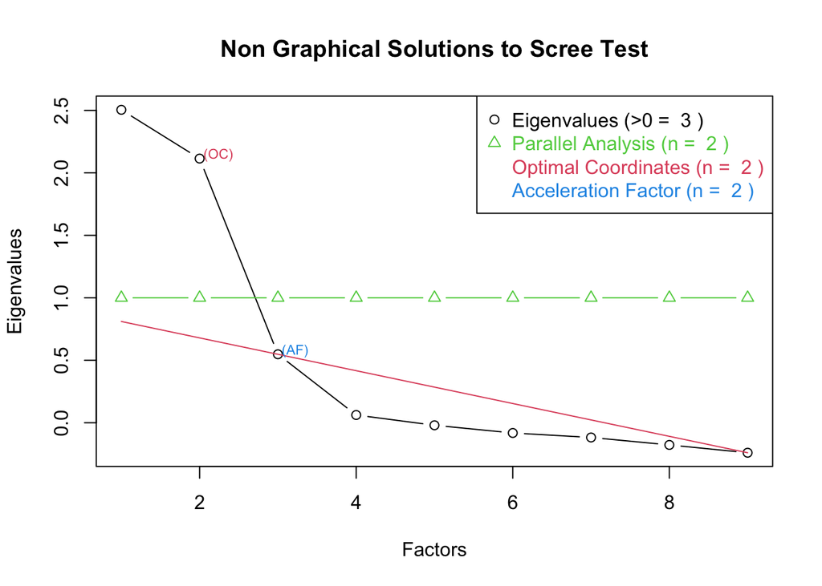

```r
plot(nScree(x=pdat2,model="factors"))
```

The information points towards 2 factors. What are those eigen values?

```r
eigen(cor(pdat2))$values
```

```
## [1] 2.9515136 2.5756903 1.1183328 0.5704920 0.5448644 0.4283432 0.3945002
## [8] 0.2616947 0.1545689
```

```r
#2-factor model
EFApdat2_2factor <- fa(r = pdat1, nfactors = 2,
                       rotate = "oblimin",
                       fm = "pa",
                       scores="regression")
EFApdat2_2factor
```

```
## Factor Analysis using method =  pa
## Call: fa(r = pdat1, nfactors = 2, rotate = "oblimin", scores = "regression",
##     fm = "pa")
## Standardized loadings (pattern matrix) based upon correlation matrix
##      PA1   PA2    h2   u2 com
## v1  0.85  0.02 0.724 0.28 1.0
## v2  0.74  0.05 0.564 0.44 1.0
## v3  0.84 -0.05 0.687 0.31 1.0
## v4  0.02  0.70 0.496 0.50 1.0
## v5  0.06  0.63 0.418 0.58 1.0
## v6  0.02  0.52 0.280 0.72 1.0
## v7 -0.18  0.43 0.179 0.82 1.3
## v8 -0.10  0.36 0.122 0.88 1.2
## v9 -0.09  0.28 0.072 0.93 1.2
##
##                        PA1  PA2
## SS loadings           2.00 1.54
## Proportion Var        0.22 0.17
## Cumulative Var        0.22 0.39
## Proportion Explained  0.57 0.43
## Cumulative Proportion 0.57 1.00
##
##  With factor correlations of
##      PA1  PA2
## PA1 1.00 0.24
## PA2 0.24 1.00
##
## Mean item complexity =  1.1
## Test of the hypothesis that 2 factors are sufficient.
##
## df null model =  36  with the objective function =  2.55 with Chi Square =  242.79
## df of  the model are 19  and the objective function was  0.48
##
## The root mean square of the residuals (RMSR) is  0.09
## The df corrected root mean square of the residuals is  0.12
##
## The harmonic n.obs is  100 with the empirical chi square  53.55  with prob <  3.9e-05
## The total n.obs was  100  with Likelihood Chi Square =  44.91  with prob <  0.00071
##
## Tucker Lewis Index of factoring reliability =  0.759
## RMSEA index =  0.116  and the 90 % confidence intervals are  0.073 0.162
## BIC =  -42.59
## Fit based upon off diagonal values = 0.9
## Measures of factor score adequacy
##                                                    PA1  PA2
## Correlation of (regression) scores with factors   0.93 0.85
## Multiple R square of scores with factors          0.86 0.72
## Minimum correlation of possible factor scores     0.72 0.44
```

```r
#3-factor model
EFApdat2_3factor <- fa(r = pdat1, nfactors = 3,
                       rotate = "oblimin",
                       fm = "pa",
                       scores="regression")
EFApdat2_3factor
```

```
## Factor Analysis using method =  pa
## Call: fa(r = pdat1, nfactors = 3, rotate = "oblimin", scores = "regression",
##     fm = "pa")
## Standardized loadings (pattern matrix) based upon correlation matrix
##      PA1   PA2   PA3   h2   u2 com
## v1  0.90 -0.04  0.06 0.79 0.21 1.0
## v2  0.74  0.05  0.00 0.56 0.44 1.0
## v3  0.80  0.02 -0.10 0.66 0.34 1.0
## v4  0.00  0.78  0.04 0.62 0.38 1.0
## v5  0.09  0.54  0.15 0.38 0.62 1.2
## v6 -0.03  0.70 -0.10 0.46 0.54 1.0
## v7 -0.03  0.01  0.73 0.54 0.46 1.0
## v8  0.02  0.04  0.51 0.27 0.73 1.0
## v9  0.03 -0.03  0.45 0.20 0.80 1.0
##
##                        PA1  PA2  PA3
## SS loadings           2.01 1.41 1.07
## Proportion Var        0.22 0.16 0.12
## Cumulative Var        0.22 0.38 0.50
## Proportion Explained  0.45 0.31 0.24
## Cumulative Proportion 0.45 0.76 1.00
##
##  With factor correlations of
##       PA1  PA2   PA3
## PA1  1.00 0.21 -0.02
## PA2  0.21 1.00  0.26
## PA3 -0.02 0.26  1.00
##
## Mean item complexity =  1
## Test of the hypothesis that 3 factors are sufficient.
##
## df null model =  36  with the objective function =  2.55 with Chi Square =  242.79
## df of  the model are 12  and the objective function was  0.15
##
## The root mean square of the residuals (RMSR) is  0.03
## The df corrected root mean square of the residuals is  0.06
##
## The harmonic n.obs is  100 with the empirical chi square  7.48  with prob <  0.82
## The total n.obs was  100  with Likelihood Chi Square =  14.19  with prob <  0.29
##
## Tucker Lewis Index of factoring reliability =  0.967
## RMSEA index =  0.042  and the 90 % confidence intervals are  0 0.116
## BIC =  -41.07
## Fit based upon off diagonal values = 0.99
## Measures of factor score adequacy
##                                                    PA1  PA2  PA3
## Correlation of (regression) scores with factors   0.94 0.87 0.81
## Multiple R square of scores with factors          0.88 0.76 0.66
## Minimum correlation of possible factor scores     0.75 0.51 0.32
```

Let’s go with the 3 factor solution. It looks a bit better all around.

With the same size p x q factor loading matrix for the two samples (here 9 x 3), we can compare the pattern of loadings between the two samples using the Tucker Index of Factor Congruence.

This is easily obatined by applying the factor.congruence function in the psych package to two factor loading matrices.

```r
fa.congruence(EFApdat1_3factor,EFApdat2_3factor)
```

```
##      PA1  PA2  PA3
## PA1 1.00 0.03 0.00
## PA2 0.03 1.00 0.04
## PA3 0.00 0.04 1.00
```

We’ve done something clever here to make a point. These two samples are actually two different persons, each of whom completed 100 days of reports (repeated measures). We have actually conducted two person-specific factor analyses. The mechanics of cross-sectional factor analysis (R-technique) and (P-technique) are identical - just the data and interpretation are different.

Our data reduction has allowed us to reduce the complexity of the 9-dimensional data.

```r
#preparing data
day <- 1:100
str(day)
```

```
##  int [1:100] 1 2 3 4 5 6 7 8 9 10 ...
```

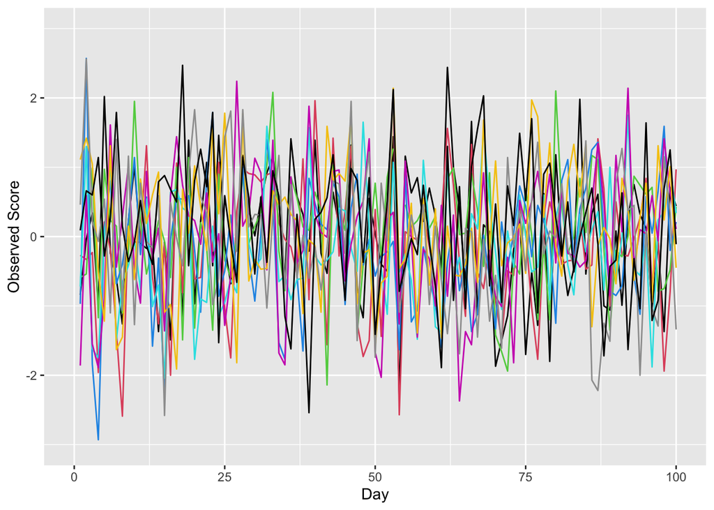

```r
pdat1_plot <- cbind(day,pdat1,EFApdat1_3factor$scores)
#Plotting observed scores
ggplot(data=pdat1_plot, aes(x=day)) +
  geom_line(aes(y=v1), color= 1) +
  geom_line(aes(y=v2), color= 2) +
  geom_line(aes(y=v3), color= 3) +
  geom_line(aes(y=v4), color= 4) +
  geom_line(aes(y=v5), color= 5) +
  geom_line(aes(y=v6), color= 6) +
  geom_line(aes(y=v7), color= 7) +
  geom_line(aes(y=v8), color= 8) +
  geom_line(aes(y=v9), color= 9) +
  xlab("Day") + ylab("Observed Score") +
  scale_x_continuous(limits=c(0,100)) +
  scale_y_continuous(limits=c(-3,3))
```

to 3-dimensional data - by setting aside 50% of the variance.

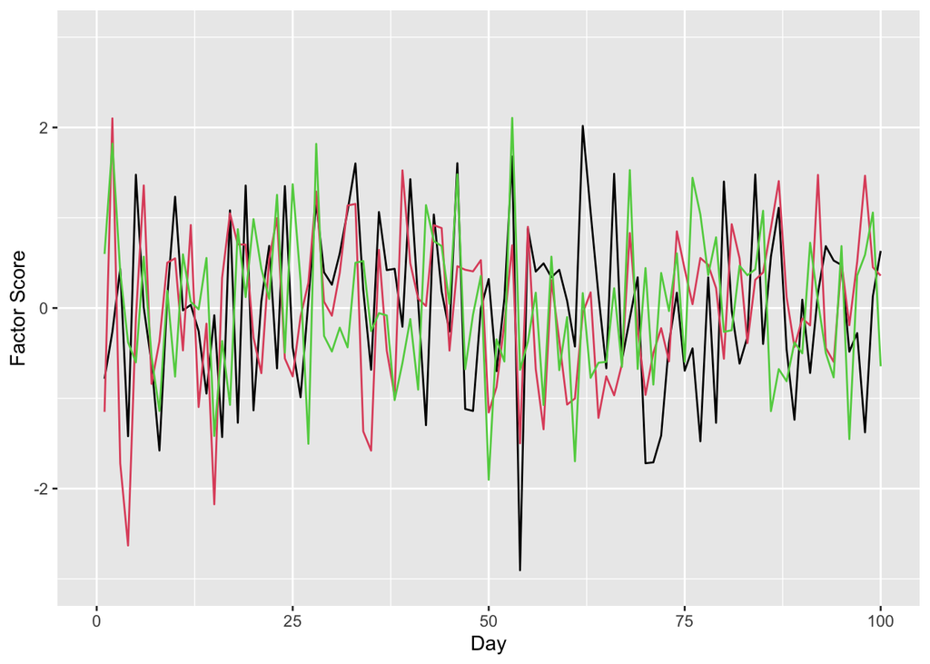

```r
#Plotting factor scores
ggplot(data=pdat1_plot, aes(x=day)) +
  geom_line(aes(y=PA1), color= 1) +
  geom_line(aes(y=PA2), color= 2) +
  geom_line(aes(y=PA3), color= 3) +
  xlab("Day") + ylab("Factor Score") +
  scale_x_continuous(limits=c(0,100)) +
  scale_y_continuous(limits=c(-3,3))
```